[GitHub](https://github.com/jverzani/QuizQuestions.jl)[](https://github.com/jverzani/QuizQuestions.jl/blob/main/docs/src/index.md)

# QuizQuestions

[QuizQuestions](https://github.com/jverzani/QuizQuestions.jl) allows the inclusion of self-grading quiz questions within a `Documenter`, `Weave`, [quarto](https://quarto.org), or `Pluto` HTML page.

A few examples:

- Quarto example
- Weave example

## Basics

The basic idea is:

- load the package:

```julia
using QuizQuestions
using LaTeXStrings # helper for using math notation
```

- create a question with `Julia` code:

```julia
choices = ["one", L"2", L"\sqrt{9}"]
question = "Which is largest?"
answer = 3
radioq(choices, answer; label=question, hint="A hint")
```

Which is largest? 🎁

$\sqrt{9}$

one

$2$

- repeat as desired.

The quizzes are written in markdown with the questions in `Julia` blocks. The above code cells would be enclosed in triple-backtick blocks and would typically have their contents hidden from the user. How this is done varies between `Documenter`, `Weave`, [quarto](https://quarto.org), and `Pluto`. The `examples` directory shows examples of each.

For each question:

- The `show` method of the object for the `text/html` mime type inserts the necessary HTML and JavaScript code to show the input widget and grading logic.
- the optional `hint` argument allows a text-only hint available to the user on hover.
- The optional `label` argument is used to flag the question.
- The optional `explanation` argument is used to give feedback to the user in case there is an incorrect answer given.

For example, the question can be asked in the body of the document (the position of any hint will be different):

```julia
answer = sqrt(2)
tol = 1e-3
numericq(answer, tol,
    label=L"What is $\sqrt{2}$?",
	hint="you need to be within 1/1000")
```

What is $\sqrt{2}$? 🎁

Using Documenter adjustment

Math markup using $\LaTeX$ in Markdown may be done with different delimiters. There are paired dollar signs (or double dollar signs); paired `\(` and `\)` (or `\[`, `\]`) delimiters; double backticks (which require no escaping); or even `math` flavors for triple backtick blocks. When displaying $\LaTeX$ in HTML, the paired parentheses are used. **However** with `Documenter` paired dollar signs are needed for markup used by `QuizQuestions`. As of `v"0.3.21"`, placing the line `ENV["QQ_LaTeX_dollar_delimiters"] = true` in `make.jl` will instruct that. This package documentation illustrates.

## Examples of question types

### Choice questions (one from many)

The `radioq` question was shown above.

The `buttonq` question is alternative to radio buttons where the correct answer is shown after the first choice. If this choice is wrong, the explanation is shown along with the correct answer.

```julia
buttonq([L"1 + 1", L"2+2", L"-1 + -1"], 1;
    label = L"Which adds to $2$?",
	explanation="Add 'em up")
```

Which adds to $2$?

### Multiple choices (one or more from many)

A multiple choice question (one or *more* from many) can be constructed with `multiq`:

```julia
choices =[
	"Four score and seven years ago",
	"Lorum ipsum",
	"The quick brown fox jumped over the lazy dog",
	"One and one and one makes three"
]
answer = (1, 4)
multiq(choices, answer,
    label="Select the sentences with numbers (one or more)")
```

Select the sentences with numbers (one or more)

The quick brown fox jumped over the lazy dog

Four score and seven years ago

One and one and one makes three

Lorum ipsum

The `multibuttonq` question is similar, but it uses a "done" button to initiate the grading. This allows for answers with $0$, $1$, or more correct answers.

```julia
choices =[
	"Four score and seven years ago",
	"Lorum ipsum",
	"The quick brown fox jumped over the lazy dog",
	"One and one and one makes three"
]
answer = (1, 4)
multibuttonq(choices, answer,
    label="Select the sentences with numbers (one or more)")
```

Select the sentences with numbers (one or more)

### Numeric answers

Questions with numeric answers use `numericq`. The question is graded when the input widget loses focus.

```julia
answer = 1 + 1
numericq(answer;
    label=L"1 + 1?",
	hint="Do the math")
```

$1 + 1?$ 🎁

Numeric questions can have an absolute tolerance set to allow for rounding.

### Text response

A question graded by a regular expression can be asked with `stringq`. The question is graded when the input widget loses focus.

```julia
stringq(r"^Washington"; label="Who was the first US president?",
        placeholder="last name")
```

Who was the first US president?

### Matching

A question involving matching can be asked with `matchq`.

```julia
questions = ("Select a Volvo", "Select a Mercedes", "Select an Audi")
choices = ("XC90", "A4", "GLE 350", "X1") # may be more than questions
answer = (1,3,2) # indices of choices that match correct answer for each question
matchq(questions, choices, answer;
    label="For each question, select the correct answer.")
```

For each question, select the correct answer.

Select a Volvo

Select a Mercedes

Select an Audi

The above shows that the number of choices need not match the number of questions. When they do, a dictionary can be used to specify the choices and the answers will be computed:

```julia
d = Dict("Select a Volvo" => "XC90", "Select a Mercedes" => "GLE 350",
         "Select an Audi" => "A4")
matchq(d, label="Match the manufacture with a model")
```

Match the manufacture with a model

Select a Mercedes

Select a Volvo

Select an Audi

### Fill-in-the-blank questions

Fill-in-the blank questions can be asked with `fillblankq`. Answers can be gathered and graded in different manners.

```julia
question = "The quick brown fox jumped over the ____ dog"
fillblankq(question, ("lazy", "brown", "sleeping"), 1)
```

The quick brown fox jumped over the Make a selection dog

(like `stringq`)

```julia
question = "The quick brown fox jumped over the ____ dog"
fillblankq(question, r"^lazy$")
```

The quick brown fox jumped over the Fill in the blank dog

(like `scriptq`)

```julia
funct = "(input) => input >= 42"
scriptq(funct, label="a large number", explanation="should be at least 6 * 7")
```

a large number

(like `numericq`)

```julia
question = "____ `` + 2  = 4``"
fillblankq(question, 2)
```

Fill in the blank $+ 2 = 4$

### Select from an image question

The `hotspotq` shows an image, specified by a file, and grades an answer correct if a mouse click is in a specified rectangular region. The region is given in terms of `(xmin,xmax)` and `(ymin, ymax)` as if the entire region was in $[0,1] \times [0,1]$, though the `correct_answer` argument allows for more complicated regions.

```julia
using Plots
p1 = plot(x -> x^2, axis=nothing, legend=false)
p2 = plot(x -> x^3, axis=nothing, legend=false)
p3 = plot(x -> -x^2, axis=nothing, legend=false)
p4 = plot(x -> -x^3, axis=nothing, legend=false)
l = @layout [a b; c d]
p = plot(p1, p2, p3, p4, layout=l)
imgfile = tempname() * ".png"
savefig(p, imgfile)
hotspotq(imgfile, (0,1/2), (0, 1/2),
    label=L"What best matches the graph of $f(x) = -x^4$?")
```

What best matches the graph of $f(x) = -x^4$?

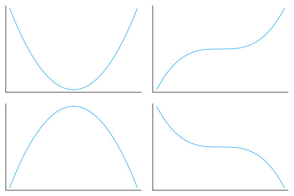

The `PlotlyLight` package provides a very lightweight interface for producing JavaScript based graphs with the `plotly.js` library. The `plotlylight` type allows questions involving an `(x,y)` selection from a graph (`(x,y)` is a point on a graph).

Note

The `plotlylight` question type does not work with `Documenter`.

## Reference

The available question types are listed below. If others are desirable, open an issue on the GitHub repository.

`QuizQuestions.radioq` — Function

```julia
radioq(choices, answer; label="", hint="", explanation="", keep_order=false)
```

Multiple choice question (one of several)

Arguments:

- `choices`: indexable collection of choices. As seen in the example, choices can be formatted with markdown.
- `answer::Int`: index of correct choice
- `keep_order::Boolean`: if `true` keeps display order of choices, otherwise they are shuffled
- `inline::Bool`: hint to render inline (or not) if supported
- `label`: optional label for the form element
- `hint`: optional plain-text hint that can be seen on hover
- `explanation`: text to display on a wrong selection

**Example:**

```
choices = ["beta", raw"``\beta``", "`beta`"]
answer = 2
radioq(choices, answer; hint="Which is the Greek symbol?")
```

[source](https://github.com/jverzani/QuizQuestions.jl/blob/6e3245a790f03fba07cbaefeea994feb4e2a01f0/src/question_types.jl#L142-L171)

`QuizQuestions.buttonq` — Function

```julia
buttonq(choices, answer; label="", hint="", [colors])
```

Use buttons for multiple choice (one of many). Show answer after first click.

Arguments:

- `choices`: indexable collection of choices. As seen in the example, choices can be formatted with markdown.
- `answer::Int`: index of correct choice
- `label`: optional label for the form element
- `hint`: optional plain-text hint that can be seen on hover
- `explanation`: text to display on a wrong selection
- `colors` a named tuple with colors for `GREEN`, `RED`, and `BLUE`

**Example:**

```
choices = ["beta", raw"``\beta``", "`beta`"]
answer = 2
explanation = "The other two answers are not a symbol, but a name"
buttonq(choices, answer; label="Which is the Greek symbol?",
        explanation=explanation)
```

[source](https://github.com/jverzani/QuizQuestions.jl/blob/6e3245a790f03fba07cbaefeea994feb4e2a01f0/src/question_types.jl#L206-L234)

`QuizQuestions.yesnoq` — Function

```julia
yesnoq(ans; [label, hint, explanation])
```

Boolean question with `yes` or `no` labels.

Examples:

```
yesnoq("yes")
yesnoq(true)
```

[source](https://github.com/jverzani/QuizQuestions.jl/blob/6e3245a790f03fba07cbaefeea994feb4e2a01f0/src/question_types.jl#L451-L463)

`QuizQuestions.booleanq` — Function

```julia
booleanq(ans; [label, hint, explanation])
```

True of false questions:

**Example:**

```
booleanq(true; label="Does it hurt...")
```

[source](https://github.com/jverzani/QuizQuestions.jl/blob/6e3245a790f03fba07cbaefeea994feb4e2a01f0/src/question_types.jl#L429-L439)

`QuizQuestions.multiq` — Function

```julia
multiq(choices, answers; label="", hint="", explanation="", keep_order=false)
```

Multiple choice question (one *or more* of several)

Arguments:

- `choices`: indexable collection of choices. As seen in the example, choices can be formatted with markdown.
- `answers::Vector{Int}`: index of correct choice(s)
- `keep_order::Boolean`: if `true` keeps display order of choices, otherwise they are shuffled
- `inline::Bool`: hint to render inline (or not) if supported
- `label`: optional label for the form element
- `hint`: optional plain-text hint that can be seen on hover
- `explanation`: text to display on a wrong selection

**Example**

```
choices = ["pear", "tomato", "banana"]
answers = [1,3]
multiq(choices, answers; label="yellow foods", hint="not the red one!")
```

[source](https://github.com/jverzani/QuizQuestions.jl/blob/6e3245a790f03fba07cbaefeea994feb4e2a01f0/src/question_types.jl#L260-L289)

`QuizQuestions.multibuttonq` — Function

```julia
multibuttonq(choices, answers; label="", hint="", explanation="", keep_order=false)
```

Multiple choice question (zero, one *or more* of several) using buttons and a "done" button to reveal the answers and whether the user input is correct.

Arguments:

- `choices`: indexable collection of choices. As seen in the example, choices can be formatted with markdown.
- `answers::Vector{Int}`: index of correct choice(s)
- `keep_order::Boolean`: if `true` keeps display order of choices, otherwise they are shuffled
- `inline::Bool`: hint to render inline (or not) if supported
- `label`: optional label for the form element
- `hint`: optional plain-text hint that can be seen on hover
- `explanation`: text to display on a wrong selection

**Example**

```
choices = ["pear", "tomato", "banana"]
answers = [1,3]
multibuttonq(choices, answers; label="yellow foods", hint="not the red one!")
```

[source](https://github.com/jverzani/QuizQuestions.jl/blob/6e3245a790f03fba07cbaefeea994feb4e2a01f0/src/question_types.jl#L315-L344)

`QuizQuestions.matchq` — Function

```julia
matchq(questions, choices, answers; label="", hint="", explanation="")
matchq(d::Dictionary; label="", hint="", explanation="")
```

Use a drop down to select the right match for each question.

Arguments:

- `questions`: Indexable collection of questions
- `choices`: indexable collection of choices for each question. As seen in the example, choices can be formatted with markdown.
- `answers`: for each question, the index from `choices` of the correct answer
- `d`: As an alternative, a dictionary of questions and answers can be specified. The choices will be taken from the values then randomized, the answers will be computed
- `label`: optional label for the form element
- `hint`: optional plain-text hint that can be seen on hover
- `explanation`: text to display on a wrong selection

**Examples**

```
questions = ("Select a Volvo", "Select a Mercedes", "Select an Audi")
choices = ("XC90", "A4", "GLE 350", "X1") # may be more than questions
answer = (1,3,2) # indices of correct
matchq(questions, choices, answer)
```

This example uses a dictionary to specify the questions and choices:

```
d = Dict("Select a Volvo" => "XC90", "Select a Mercedes" => "GLE 250")
matchq(d)
```

[source](https://github.com/jverzani/QuizQuestions.jl/blob/6e3245a790f03fba07cbaefeea994feb4e2a01f0/src/question_types.jl#L369-L407)

`QuizQuestions.numericq` — Function

```julia
numericq(value, atol=1e-3; label="", hint="", units="", explanation="", placeholder=nothing)
```

Match a numeric answer

Arguments:

- `value`: the numeric answer
- `atol`: $|\mathrm{answer} - \mathrm{value}| \le \mathrm{atol}$ is used to determine correctness
- `label`: optional label for the form element
- `hint`: optional plain-text hint that can be seen on hover
- `units`: a string indicating expected units
- `placeholder`: text shown when input widget is initially drawn

[source](https://github.com/jverzani/QuizQuestions.jl/blob/6e3245a790f03fba07cbaefeea994feb4e2a01f0/src/question_types.jl#L97-L116)

`QuizQuestions.stringq` — Function

```julia
stringq(re::Regex; filter::Regex=r"", label="", hint="", explanation="", placeholder="")
```

Match string answer with regular expression

Arguments:

- `re`: a regular expression for grading
- `filter`: a regular expression for what to remove from the string before matching (e.g. `r"\s"` to remove whitespace)
- `label`: optional label for the form element
- `hint`: optional plain-text hint that can be seen on hover
- `explanation`: text to display on a wrong selection
- `placeholder`: text shown when input widget is initially drawn

**Example**

```
re = Regex("^abc")
stringq(re, label="First 3 letters...")
```

[source](https://github.com/jverzani/QuizQuestions.jl/blob/6e3245a790f03fba07cbaefeea994feb4e2a01f0/src/question_types.jl#L12-L38)

`QuizQuestions.scriptq` — Function

```julia
scriptq(funct::AbstractString, runonce::AbstractString=""; label="", hint="", explanation="", placeholder="")
```

Check string answer with custom script

Arguments:

- `funct`: a string representing the name of a JavaScript function/closure of signature `(str: string): boolean`
- `label`: optional label for the form element
- `hint`: optional plain-text hint that can be seen on hover
- `explanation`: text to display on a wrong selection
- `placeholder`: text shown when input widget is initially drawn

**Example**

```javascript
// in JavaScript
function threshold(t) {
    return (input) => input >= t;
}
```

```julia
# in Julia
stringq("threshold(42)", label="A large number")
```

[source](https://github.com/jverzani/QuizQuestions.jl/blob/6e3245a790f03fba07cbaefeea994feb4e2a01f0/src/question_types.jl#L51-L82)

`QuizQuestions.fillblankq` — Function

```julia
fillblankq(question answer::Regex; placeholder=nothing, [label, hint, explanation])
fillblankq(question, choices, answer; keep_order=false,[label, hint, explanation])
fillblankq(question, val, atol=0; placeholder=nothing, [label, hint, explanation])
```

Present a fill-in-the-blank question where the blank can be a selection, a number, or a string graded by a regular expression.

- `question`: A string. Use `____` (4 or more under scores) to indicate the blank.

Other rguments from `stringq`, `radioq`, and `numericq`

**Examples**

```
question = "The quick brown fox jumped over the ____ dog"
fillblankq(question, r"lazy")
fillblankq(question, ("lazy", "brown", "sleeping"), 1)
fillblankq("____ ``+ 2  = 4``", 2)
```

[source](https://github.com/jverzani/QuizQuestions.jl/blob/6e3245a790f03fba07cbaefeea994feb4e2a01f0/src/question_types.jl#L500-L518)

`QuizQuestions.hotspotq` — Function

```julia
hotspotq(imagefile, xs, ys=(0,1); label="", hint="", explanation="",
    correct_answer=nothing)
```

Question type to check if user clicks in a specified region of an image.

- `imgfile`: File of an image. The images will be encoded and embedded in the web page.
- `xs`: iterable specifying `(xmin, xmax)` with `0 <= xmin <= xmax <= 1`
- `ys`: iterable specifying `(ymin, ymax)`
- `correct_answer`: A text snippet of JavaScript which can be specified to add more complicated logic to test if an answer is correct. It must use `x` and `y` for the coordinates of the click.

**Examples**

```
using Plots
p1 = plot(x -> x^2, axis=nothing, legend=false)
p2 = plot(x -> x^3, axis=nothing, legend=false)
p3 = plot(x -> -x^2, axis=nothing, legend=false)
p4 = plot(x -> -x^3, axis=nothing, legend=false)
l = @layout [a b; c d]
p = plot(p1, p2, p3, p4, layout=l)
imgfile = tempname() * ".png"
savefig(p, imgfile)
hotspotq(imgfile, (0,1/2), (0, 1/2), label="What best matches the graph of ``f(x) = -x^4``?")
```

Note

The display of the image is not adjusted by this question type and must be managed separately.

[source](https://github.com/jverzani/QuizQuestions.jl/blob/6e3245a790f03fba07cbaefeea994feb4e2a01f0/src/question_types.jl#L556-L589)

`QuizQuestions.plotlylightq` — Function

```julia
plotlylightq(p, xs=(-Inf, Inf), ys=(-Inf, Inf);
             label="", hint="", explanation="",
             correct_answer=nothing)
```

From a plotly graph of a function present a question about the `x-y` point on a graph shown on hover. (For figures with multiple graphs, the hover of the first one is taken. For parameterized plots, the hover may be computed in an unexpected manner.)

By default, correct answers select a value on the graph with `x` in the range specified by `xs` and `y` in the range specified by `ys`.

- `xs`: specifies interval for selected point `[x₀,x₁]`, defaults to `(-Inf,Inf)`
- `ys`: range `[y₀,y₁]`
- `correct_answer`: When specified, allows more advanced notions of correct. This is a JavaScript code snippet with `x` and `y` representing the hovered point on the graph that is highlighted on clicking.

**Examples**

```
using PlotlyLight
xs = range(0, 2pi, length=100)
ys = sin.(xs)
p = Plot(Config(x=xs, y=ys))
plotlylightq(p, (3,Inf); label="Click a value with ``x>3``")
```

An example where the default grading script needs modification. Note also, the `x`, `y` values refer to the *first* graph. (One could modify their definition in `correct answer`; they are found through `x=e.points[0].x`, `y=e.points[0].y`.)

```
xs = range(0, 2pi, length=100)
ys = sin.(xs)
p = Plot(Config(x=xs, y=ys));
push!(p.data, Config(x=xs, y=cos.(xs)));  # add layer
question = "Click a value where `sin(x)` is increasing"
# evalute pi/2 as no pi in JavaScript, also Inf -> Infinity
correct_answer = "((x >= 0 && x <= 1.5707963267948966) || (x >= 4.71238898038469 && x <= 6.283185307179586))"
plotlylightq(p; label=question, correct_answer=correct_answer)
```

Note

The use of `PlotlyLight` graphics works with `Weave` and `Pluto`, but is unusable from `quarto` and `Documenter`.

[source](https://github.com/jverzani/QuizQuestions.jl/blob/6e3245a790f03fba07cbaefeea994feb4e2a01f0/src/question_types.jl#L608-L653)

`QuizQuestions.scorecard` — Function

```julia
scorecard(values; oncompletion::Bool=false, not_completed_msg::String="", which_attempt=:completed)
```

Add a scorecard

- `values` is a collection of pairs, `interval => message`. See below. The default summarizes the number of correct/attempted of the number of questions attempted and the total number of questions.
- The `oncompletion` flag can be set to only show the message if all the questions have been attempted. When set, and not all questions have been attempted, the `not_completed_msg` message is shown.
- `which_percent` is either `:correct` or `:attempted`

The interval is specified as `(l,r)`, with `0 <= l < r <= 100`, or *optionally* as `(l,r,interval_type)` where `interval_type`, a string, is one of `"[]"`, `"[)"`,`"(]"`, or `"()"`. The default interval type is `"[)"` unless `r` is `100`, in which case it is `"[]"`.

The message is shown when the percent correct/attempted is in the interval. The following values are substituted, when present:

- `{{:total_questions}}` - the number of total questions
- `{{:correct}}` - the number of correct answers
- `{{:attempted}}` - the number of attempted questions
- `{{:total_attempts}}` – the number of attempts.

The message may have Markdown formatting.

Example

```
vals = [(0,99)=>"Keep trying",
          (99, 100) => "You got {{:correct}} **correct** of {{:total_questions}} total *questions*"]
scorecard(vals)
```

[source](https://github.com/jverzani/QuizQuestions.jl/blob/6e3245a790f03fba07cbaefeea994feb4e2a01f0/src/question_types.jl#L669-L698)